# Wie zijn de beste sporters?

## Omschrijving

Deze eindopdracht draait om de statistieken van de spelers in het populaire videospel FIFA 21.

Wie is de beste voetballer? Dat is een vraag die ingewikkeld is om te beantwoorden, en veel mensen komen met verschillende antwoorden. Aan jou de taak om een definitief antwoord te geven met behulp van je data engineering skills!

Verzamel zelf je data, manipuleer de data tot het bruikbaar is en maak vervolgens mooie visualisaties van je data! Documenteer al je stappen in een Jupyter Notebook, en zorg ervoor dat de lezer begrijpt hoe je tot je conclusie bent gekomen.

Geef jouw eigen antwoord op de volgende vragen:

- Wie is de beste aanvaller? Geef een top 10;
- Wie is de beste keeper? Geef een top 10;
- Wie is de beste trainer? Geef een top 10.
- Houd het simpel en bekijk alleen voetbalwedstrijden die in het afgelopen kalenderjaar (1 januari t/m 31 december) hebben plaatsgevonden. Trek op basis van die wedstrijden de conclusie wie de beste voetballer is!

## Leerdoelen

In dit project gebruik jij zelfstandig al jouw verkregen kennis over data engineering en gebruik je die om in je eentje een volledige database te bouwen op basis waarvan goede inzichten kunnen vrekregen.

## Verwachte uitkomst

Je levert een Jupyter Notebook in waarin jij verslag doet van wie de beste aanvaller, trainer en keeper in het afgelopen jaar waren in de voetbalsport - of de beste sporters in een andere sport naar keuze.

## Uitwerking

Importeer alle belangrijke python pakketten voor data manipulatie en visualisatie.

```python
#Gegevens Manipulatie
import pandas as pd
#Gegevens Visualisatie
import matplotlib.pyplot as plt
import seaborn as sns
```

```python
# Importeer data
data = pd.read_csv("players_21.csv")
```

```python
# Kijk naar data
data.head()
```

|  | sofifa_id | player_url | short_name | long_name | age | dob | height_cm | weight_kg | nationality | club_name | ... | lwb | ldm | cdm | rdm | rwb | lb | lcb | cb | rcb | rb |
| --- | --- | --- | --- | --- | --- | --- | --- | --- | --- | --- | --- | --- | --- | --- | --- | --- | --- | --- | --- | --- | --- |
| 0 | 158023 | https://sofifa.com/player/158023/lionel-messi/... | L. Messi | Lionel Andrés Messi Cuccittini | 33 | 1987-06-24 | 170 | 72 | Argentina | FC Barcelona | ... | 66+3 | 65+3 | 65+3 | 65+3 | 66+3 | 62+3 | 52+3 | 52+3 | 52+3 | 62+3 |
| 1 | 20801 | https://sofifa.com/player/20801/c-ronaldo-dos-... | Cristiano Ronaldo | Cristiano Ronaldo dos Santos Aveiro | 35 | 1985-02-05 | 187 | 83 | Portugal | Juventus | ... | 65+3 | 61+3 | 61+3 | 61+3 | 65+3 | 61+3 | 54+3 | 54+3 | 54+3 | 61+3 |
| 2 | 200389 | https://sofifa.com/player/200389/jan-oblak/210002 | J. Oblak | Jan Oblak | 27 | 1993-01-07 | 188 | 87 | Slovenia | Atlético Madrid | ... | 32+3 | 36+3 | 36+3 | 36+3 | 32+3 | 32+3 | 33+3 | 33+3 | 33+3 | 32+3 |
| 3 | 188545 | https://sofifa.com/player/188545/robert-lewand... | R. Lewandowski | Robert Lewandowski | 31 | 1988-08-21 | 184 | 80 | Poland | FC Bayern München | ... | 64+3 | 65+3 | 65+3 | 65+3 | 64+3 | 61+3 | 60+3 | 60+3 | 60+3 | 61+3 |
| 4 | 190871 | https://sofifa.com/player/190871/neymar-da-sil... | Neymar Jr | Neymar da Silva Santos Júnior | 28 | 1992-02-05 | 175 | 68 | Brazil | Paris Saint-Germain | ... | 67+3 | 62+3 | 62+3 | 62+3 | 67+3 | 62+3 | 49+3 | 49+3 | 49+3 | 62+3 |

5 rows × 106 columns

```python
# Controleer de kolommen in onze Dataset
data.columns
```

```
Index(['sofifa_id', 'player_url', 'short_name', 'long_name', 'age', 'dob',
       'height_cm', 'weight_kg', 'nationality', 'club_name',
       ...
       'lwb', 'ldm', 'cdm', 'rdm', 'rwb', 'lb', 'lcb', 'cb', 'rcb', 'rb'],
      dtype='object', length=106)
```

```python
# Meer informatie over de dataset
data.info()
```

```
<class 'pandas.core.frame.DataFrame'>
RangeIndex: 18944 entries, 0 to 18943
Columns: 106 entries, sofifa_id to rb
dtypes: float64(18), int64(44), object(44)
memory usage: 15.3+ MB
```

```python
# Verwijder kolom die niet nodig zijn.
new_data = data.drop(columns =['body_type', 'short_name', 'player_url', 'ls', 'st', 'rs', 'lw', 'lf', 'cf', 'rf', 'rw', 'lam', 'cam', 'ram', 'lm', 'lcm', 'cm', 'rcm', 'rm', 'lwb', 'ldm', 'cdm', 'rdm', 'rwb', 'lb', 'lcb', 'cb', 'rcb', 'rb'])
```

```python
# Kolomnaam veranderen
new_data.rename(columns = {'long_name':'name'}, inplace = True)
```

```python
# Controleer nieuwe dataset of de kolommen zijn verwijderd
new_data.head()
```

|  | sofifa_id | name | age | dob | height_cm | weight_kg | nationality | club_name | league_name | league_rank | ... | mentality_penalties | mentality_composure | defending_marking | defending_standing_tackle | defending_sliding_tackle | goalkeeping_diving | goalkeeping_handling | goalkeeping_kicking | goalkeeping_positioning | goalkeeping_reflexes |
| --- | --- | --- | --- | --- | --- | --- | --- | --- | --- | --- | --- | --- | --- | --- | --- | --- | --- | --- | --- | --- | --- |
| 0 | 158023 | Lionel Andrés Messi Cuccittini | 33 | 1987-06-24 | 170 | 72 | Argentina | FC Barcelona | Spain Primera Division | 1.0 | ... | 75 | 96 | NaN | 35 | 24 | 6 | 11 | 15 | 14 | 8 |
| 1 | 20801 | Cristiano Ronaldo dos Santos Aveiro | 35 | 1985-02-05 | 187 | 83 | Portugal | Juventus | Italian Serie A | 1.0 | ... | 84 | 95 | NaN | 32 | 24 | 7 | 11 | 15 | 14 | 11 |
| 2 | 200389 | Jan Oblak | 27 | 1993-01-07 | 188 | 87 | Slovenia | Atlético Madrid | Spain Primera Division | 1.0 | ... | 11 | 68 | NaN | 12 | 18 | 87 | 92 | 78 | 90 | 90 |
| 3 | 188545 | Robert Lewandowski | 31 | 1988-08-21 | 184 | 80 | Poland | FC Bayern München | German 1. Bundesliga | 1.0 | ... | 88 | 88 | NaN | 42 | 19 | 15 | 6 | 12 | 8 | 10 |
| 4 | 190871 | Neymar da Silva Santos Júnior | 28 | 1992-02-05 | 175 | 68 | Brazil | Paris Saint-Germain | French Ligue 1 | 1.0 | ... | 92 | 93 | NaN | 30 | 29 | 9 | 9 | 15 | 15 | 11 |

5 rows × 77 columns

## Top 10 spelers

```python
#Laat top 10 spelers overall zien
spelers = new_data.sort_values('overall', ascending=False)[['name', 'overall', 'age', 'club_name', 'player_positions']].head(10)
spelers.set_index("name", inplace=True)
spelers.style
```

| name | overall | age | club_name | player_positions |
| --- | --- | --- | --- | --- |
| Lionel Andrés Messi Cuccittini | 93 | 33 | FC Barcelona | RW, ST, CF |
| Cristiano Ronaldo dos Santos Aveiro | 92 | 35 | Juventus | ST, LW |
| Jan Oblak | 91 | 27 | Atlético Madrid | GK |
| Robert Lewandowski | 91 | 31 | FC Bayern München | ST |
| Neymar da Silva Santos Júnior | 91 | 28 | Paris Saint-Germain | LW, CAM |
| Kevin De Bruyne | 91 | 29 | Manchester City | CAM, CM |
| Alisson Ramsés Becker | 90 | 27 | Liverpool | GK |
| Sadio Mané | 90 | 28 | Liverpool | LW |
| Mohamed Salah Ghaly | 90 | 28 | Liverpool | RW |
| Virgil van Dijk | 90 | 28 | Liverpool | CB |

## Top 10 keepers

```python
# Maak dataset met alleen keepers
data_keepers = new_data.loc[new_data['player_positions'] == 'GK']
```

```python
# Maak overzicht met top 10 keepers
keepers = data_keepers.sort_values('overall', ascending=False)[['name', 'overall', 'age', 'club_name']].head(10)
keepers.set_index('name', inplace=True)
keepers.style
```

| name | overall | age | club_name |
| --- | --- | --- | --- |
| Jan Oblak | 91 | 27 | Atlético Madrid |
| Alisson Ramsés Becker | 90 | 27 | Liverpool |
| Marc-André ter Stegen | 90 | 28 | FC Barcelona |
| Thibaut Courtois | 89 | 28 | Real Madrid |
| Manuel Neuer | 89 | 34 | FC Bayern München |
| Ederson Santana de Moraes | 88 | 26 | Manchester City |
| Samir Handanovič | 88 | 35 | Inter |
| Keylor Navas Gamboa | 87 | 33 | Paris Saint-Germain |
| Wojciech Szczęsny | 87 | 30 | Juventus |
| Hugo Lloris | 87 | 33 | Tottenham Hotspur |

## Leeftijd analyse

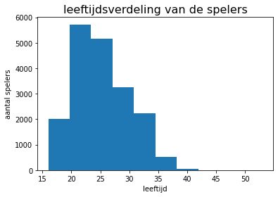

```python
# Age Distribution of Dataset
x = new_data.age
plt.hist(x)
plt.xlabel("leeftijd")
plt.ylabel("aantal spelers")
plt.title("leeftijdsverdeling van de spelers", fontsize=16)
plt.show()
```

```python
# print mediaan en gemiddelde leeftijd
print('Mediaan leeftijd = ', new_data.age.median())
print('Gemiddelde leeftijd = ', new_data.age.mean())
```

```
Mediaan leeftijd =  25.0
Gemiddelde leeftijd =  25.22582347972973
```

```python
# oudste speler
oudste_speler = new_data.sort_values('age', ascending=False)[['name', 'nationality', 'age', 'dob','club_name']].head(1)
oudste_speler.set_index('name', inplace=True)
oudste_speler.style
```

| name | nationality | age | dob | club_name |
| --- | --- | --- | --- | --- |
| Kazuyoshi Miura | Japan | 53 | 1967-02-26 | Yokohama FC |

```python
# jongste speler
jongste_speler = new_data[new_data['age'] < 20].sort_values(by='dob', ascending=False)[['name', 'nationality', 'age', 'dob','club_name']].head(1)
jongste_speler.set_index('name', inplace=True)
jongste_speler
```

| name | nationality | age | dob | club_name |
| --- | --- | --- | --- | --- |
| Rico Richards | England | 16 | 2003-09-27 | West Bromwich Albion |

```python
# Kijk naar de meest veelbelovende jongste speler
jongste_speler = new_data[(new_data['potential'] > 85) & (new_data['age'] < 18)].sort_values(by='potential', ascending=False)[['name', 'nationality', 'age', 'potential','club_name']].head(5)
jongste_speler.set_index('name', inplace=True)
jongste_speler
```

| name | nationality | age | potential | club_name |
| --- | --- | --- | --- | --- |
| Anssumane Fati | Spain | 17 | 90 | FC Barcelona |
| Eduardo Camavinga | France | 17 | 88 | Stade Rennais FC |
| Pedro González López | Spain | 17 | 88 | FC Barcelona |
| Jude Bellingham | England | 17 | 88 | Borussia Dortmund |
| Florian Wirtz | Germany | 17 | 88 | Bayer 04 Leverkusen |

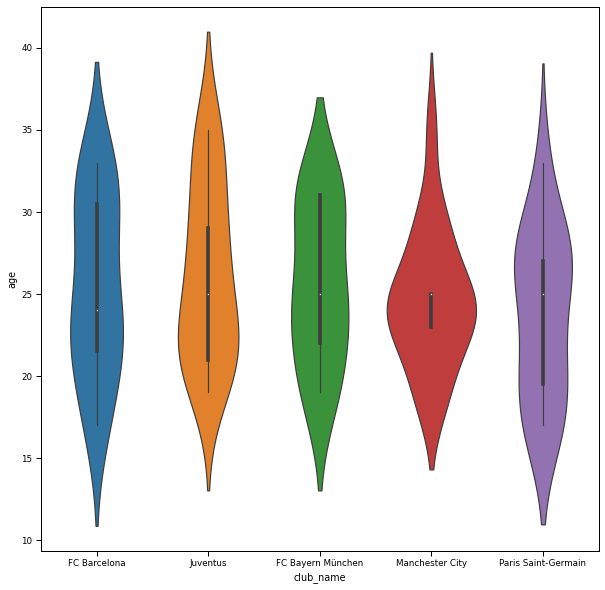

```python
# Kijk naar de leeftijdsverdeling in de 5 best voetballende landen
selected_clubs = ("FC Barcelona", "Juventus", "Paris Saint-Germain", "Manchester City", "FC Bayern München")
# Then we assign the value from the data set
club_age = new_data[new_data["club_name"].isin(selected_clubs) & new_data["age"]]

#Then we make a violin plot
plt.figure(figsize=(10, 10))
sns.violinplot(x="club_name", y="age", data=club_age)
sns.set_context("paper")
```